# Atividade - Moneyball

2024-11-07

> It’s about getting things down to one number. Using stats the way we read them, we’ll find the value in players that nobody else can see. Peter Brand in Moneyball

O ano é 2001. Você foi contratado para ajudar a aproveitar ao máximo o orçamento cada vez menor de jogadores do time de beisebol *Oakland Athletics*. Todos os anos, times de elite contratam novos jogadores de beisebol. Infelizmente, você está com poucos jogadores famosos – e com poucos fundos. Porém, com um pouco de SQL e um pouco de sorte, quem disse que ainda não é possível criar uma equipe que desafie as expectativas?

Com um banco de dados chamado `moneyball.db` – que contém informações sobre jogadores, seu desempenho e seus salários – ajude o *Oakland Athletics* a encontrar o valor em jogadores que outros podem perder.

As informações estão contidas no banco de dados `moneyball.db` BAIXAR

## Schema

`moneyball.db` representa todos os jogadores, equipes, salários e desempenhos da **Liga Principal de Beisebol** até 2001. Em particular, `moneyball.db` representa as seguintes entidades:

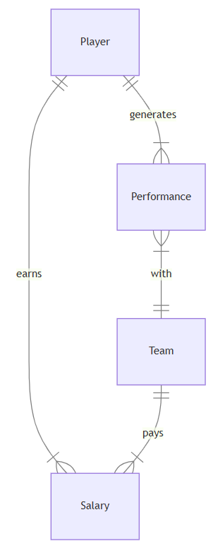

Dentro de `moneyball.db`, você encontrará diversas tabelas que implementam os relacionamentos descritos no diagrama acima. Clique nos menus suspensos abaixo para saber mais sobre o esquema de cada tabela individual.

**tabela players** (jogadores)**

A tabela players contém as seguintes colunas:

- `id`: identifica o id do djogador
- `first_name`: o primeiro nome do jogador
- `last_name`: último nome do jogador
- `bats`: é o lado em que o jogador rebate (“L” para *left* e “R” para *right*)
- `throws`: é a mão que o jogador usa para lançar a bola (“L” para *left* e “R” para *right*)
- `weight`: o peso do jogador em libras
- `height`: a altura do jogador em polegadas
- `debut`: a data (expressa como `YYYY-MM-DD`) em que o jogador fez seu primeiro jogo
- `final_game`: a data (expressa como `YYYY-MM-DD`) em que o jogador fez seu último jogo
- `birth_year`: ano em que o jogador nasceu
- `birth_month`: mês em que o jogador nasceu
- `birth_day`: dia em que o jogador nasceu
- `birth_city`: cidade em que o jogador nasceu
- `birth_state`: estado em que o jogador nasceu
- `birth_country`: país em que o jogador nasceu

**tabela teams** (times)**

A tabela teams contém as seguintes colunas:

- `id`: identifica o id de cada time
- `year`: ano em que o time foi formado
- `name`: o nome do time
- `park`: o nome do parque em que o time joga (ou jogava)

**tabela performances** (performances)**

A tabela performances contém as seguintes colunas:

- `id`: identifica o id da performance
- `player_id`: id do jogador que teve a performance
- `team_id`: id do time para o qual o jogador teve a performance
- `year`: ano em que o jogador teve a performance
- `G`: número de jogos que o jogador fez, para aquela time, naquele ano
- `AB`: que é o número de “preparos de rebatidas” do jogador (ou seja, vezes em que ele levantou o taco para rebater), para um determinado time, em um determinado ano
- `H`: que é o número de rebatidas do jogador, para um determinado time, em um determinado ano
- `2B`: que é o número de duplas (rebatidas de duas bases) do jogador, para um determinado time, em um determinado ano
- `3B`: que é o número de triplos (rebatidas de três bases) do jogador, para um determinado time, em um determinado ano
- `HR`: que é o número de *home runs* do jogador, para um determinado time, em um determinado ano
- `RBI`: que é o número de “corridas impulsionadas” do jogador (ou seja, corridas marcadas), para uma determinada equipe, em um determinado ano
- `SB`: que é o número de bases roubadas do jogador, para um determinado time, em um determinado ano

**tabela salaries** (salários)**

A tabela salaries contém as seguintes colunas:

- `id`: identifica o id do salário
- `player_id`: id do jogador que recebe o salário
- `team_id`: id do time que está pagando o salário
- `year`: o ano em que o salário foi pago

## Problema para resolver

Para cada uma das perguntas a seguir, você deve escrever uma única query SQL que produza os resultados especificados por cada problema. Sua resposta deve assumir a forma de uma única consulta SQL.

1. Você deve começar estudando como os salários médios dos jogadores mudaram ao longo do tempo. Escreva uma consulta SQL para encontrar o salário médio dos jogadores por ano.
- Ordene por ano de forma decrescente.
- Arredonde o salário com duas casas decimais e nomeie a coluna como “salário médio”.
2. Seu gerente geral (ou seja, a pessoa que toma decisões sobre os contratos dos jogadores) pergunta se o time deveria trocar um jogador atual por Cal Ripken Jr., um craque que provavelmente está se aposentando. Escreva uma consulta SQL para encontrar o histórico salarial de Cal Ripken Jr (ordene por ano de forma decrescente).
3. Seu time vai precisar de um grande rebatedor de home runs. Ken Griffey Jr., vencedor de longa data dos prêmios Silver Slugger e Gold Glove, pode ser uma boa opção. Escreva uma consulta SQL para encontrar o histórico de home runs de Ken Griffey Jr.
- Ordene por ano de forma decrescente.
- Observe que pode haver dois jogadores com o nome “Ken Griffey”. Este Ken Griffey nasceu em 1969.
- Sua consulta deve retornar uma tabela com duas colunas, uma para o ano e outra para home runs.
4. Você precisa fazer uma recomendação sobre quais jogadores o time deve considerar contratar. Com o orçamento cada vez menor do time, o gerente geral quer saber quais jogadores receberam os salários mais baixos em 2001. Escreva uma consulta SQL para encontrar os 50 jogadores que menos receberam em 2001.
- Ordene os jogadores por salário, do menor para o maior
5. Escreva uma consulta SQL para encontrar todos os times pelos quais Satchel Paige jogou.
6. Escreva uma consulta SQL para retornar os 5 melhores times, classificados pelo número total de acertos dos jogadores em 2001.
7. Você precisa fazer uma recomendação sobre qual jogador (ou jogadores) evitar o recrutamento. Escreva uma consulta SQL para encontrar o nome do jogador que recebeu o salário mais alto de todos os tempos.
8. Quanto precisariam pagar para conseguir o melhor rebatedor de home run da temporada passada? Escreva uma consulta SQL para encontrar o salário (DE 2001) do jogador que acertou mais home runs em 2001.
9. Quais salários as outras equipes estão pagando? Escreva uma consulta SQL para encontrar as 5 equipes com salários mais baixos (por salário médio) em 2001.
- Arredonde a coluna do salário médio para duas casas decimais e chame-a de “salário médio”.
- Ordene as equipes por salário médio, do menor para o maior.
10. O gerente geral pediu a você um relatório que detalha o nome de cada jogador, seu salário por ano em que jogou e o número de home runs em cada ano em que jogou. Para ser mais preciso, a tabela deve incluir:
- O primeiro nome dos jogadores.
- O último nome dos jogadores.
- O salário dos jogadores.
- Os home runs dos jogadores.
- O ano em que o jogador recebeu aquele salário E acertou os home runs.

(Considere um caso secundário: suponha que um jogador tenha vários salários ou desempenhos em um determinado ano. Ordene-os primeiro pelo número de home runs, em ordem decrescente, seguido pelo salário, em ordem decrescente.) Tenha o cuidado de garantir que, para uma única linha, o ano do salário e o ano do desempenho correspondam.

**tabela exemplo**

Para ajudá-lo a visualizar o que o gerente geral gostaria, eles lhe deram uma tabela de exemplo:

| first_name | last_name | salary | year | HR |
| --- | --- | --- | --- | --- |
| Don | Aase | 400000 | 1989 | 0 |
| Don | Aase | 675000 | 1988 | 0 |
| Don | Aase | 625000 | 1987 | 0 |
| Don | Aase | 600000 | 1986 | 0 |
| Jeff | Abbott | 300000 | 2001 | 0 |
| Jeff | Abbott | 255000 | 2000 | 3 |
| Jeff | Abbott | 255000 | 1999 | 2 |

Se tudo correr bem, você também poderá ver duas linhas como esta em sua tabela final:

| first_name | last_name | salary | year | HR |
| --- | --- | --- | --- | --- |
| Todd | Zeile | 3700000 | 1995 | 9 |
| Todd | Zeile | 3700000 | 1995 | 5 |

11. Você precisa de um jogador que consiga acertar. Quem pode ser o mais subestimado? Escreva uma consulta SQL para encontrar os 10 jogadores mais baratos por hit em 2001.
- Sua consulta deve retornar uma tabela com três colunas, uma para os nomes dos jogadores, uma para os sobrenomes e outra chamada “dólares por acerto”.
- Você pode calcular a coluna “dólares por acerto” dividindo o salário de um jogador em 2001 pelo número de acertos que ele fez em 2001. Lembre-se de que você pode usar AS para renomear uma coluna.
- Dividir um salário por 0 acertos resultará em um valor NULO. Evite o problema filtrando jogadores com 0 acertos.
- Classifique a tabela pela coluna “dólares por acerto”, do menos para o mais caro. Se dois jogadores tiverem os mesmos “dólares por acerto”, ordene pelo nome, seguido do sobrenome, em ordem alfabética.
- Assim como na questão 10, certifique-se de que o ano do salário e o ano do desempenho correspondam.
- Você pode assumir, para simplificar, que um jogador terá apenas um salário e um desempenho em 2001.
12. Rebatidas são ótima, mas os RBIs (“**runs batted in**” - corridas marcadas) também! Escreva uma consulta SQL para encontrar os 10 jogadores mais baratos por hit *E* entre mais baratos por RBI.
- Sua consulta deve retornar uma tabela com duas colunas, uma para os nomes dos jogadores e outra para os sobrenomes.
- Você pode calcular o salário de um jogador por RBI dividindo o salário de 2001 pelo número de RBIs em 2001.
- Você pode assumir, para simplificar, que um jogador terá apenas um salário e um desempenho em 2001.
- Ordene seus resultados por ID de jogador, do menor para o maior (ou em ordem alfabética pelo sobrenome, já que ambos são iguais neste caso!).
- Use o que aprendeu nas consultas 10 e 11.

## RESPOSTAS

**Ver**

#### 1 Você deve começar estudando como os salários médios dos jogadores mudaram ao longo do tempo. Escreva uma consulta SQL para encontrar o salário médio dos jogadores por ano.

```sql
SELECT "year",ROUND(AVG("salary"),2) as "MEDIA" FROM "salaries"
GROUP BY "year"
ORDER BY "year" DESC;
```

**Ver resultado**

|  | year | MEDIA |
| --- | --- | --- |
| 1 | 2001 | 2279841.06 |
| 2 | 2000 | 1992984.57 |
| 3 | 1999 | 1485316.85 |
| 4 | 1998 | 1280844.56 |
| 5 | 1997 | 1218687.44 |
| 6 | 1996 | 1027909.29 |
| 7 | 1995 | 964979.07 |
| 8 | 1994 | 1049588.56 |
| 9 | 1993 | 976966.56 |
| 10 | 1992 | 1047520.58 |

[output cut: 7 more lines]

#### 2 Seu gerente geral (ou seja, a pessoa que toma decisões sobre os contratos dos jogadores) pergunta se o time deveria trocar um jogador atual por Cal Ripken Jr., um craque que provavelmente está se aposentando. Escreva uma consulta SQL para encontrar o histórico salarial de Cal Ripken Jr (ordene por ano de forma decrescente)

```sql
SELECT "year","salary" FROM "salaries" WHERE "player_id" = (
    SELECT "id" FROM "players" WHERE ("first_name" = "Cal") AND ("last_name" =        "Ripken")
    )
ORDER BY "year" DESC;
```

**Ver resultado**

|  | year | salary |
| --- | --- | --- |
| 1 | 2001 | 6300000 |
| 2 | 2000 | 6300000 |
| 3 | 1999 | 6500000 |
| 4 | 1998 | 6400000 |
| 5 | 1997 | 6850000 |
| 6 | 1996 | 6650000 |
| 7 | 1995 | 6700000 |
| 8 | 1994 | 5500000 |
| 9 | 1993 | 5200000 |
| 10 | 1992 | 2100000 |

[output cut: 7 more lines]

Existem 2 jogadores com esse nome, é preciso encontrar o Jr, ou seja, o mais novo (que nasceu em uma data mais tardia)

```sql
SELECT "year", "H" FROM "performances" WHERE "player_id" = (
    SELECT "id" FROM "players" WHERE ("first_name" = "Ken" AND "last_name" LIKE       "Griffey")
    ORDER BY "birth_year" DESC LIMIT 1 )
ORDER BY "performances".year DESC;
```

**Ver resultado**

|  | year | H |
| --- | --- | --- |
| 1 | 2001 | 104 |
| 2 | 2000 | 141 |
| 3 | 1999 | 173 |
| 4 | 1998 | 180 |
| 5 | 1997 | 185 |
| 6 | 1996 | 165 |
| 7 | 1995 | 67 |
| 8 | 1994 | 140 |
| 9 | 1993 | 180 |
| 10 | 1992 | 174 |

[output cut: 3 more lines]

#### 4 Você precisa fazer uma recomendação sobre quais jogadores o time deve considerar contratar. Com o orçamento cada vez menor do time, o gerente geral quer saber quais jogadores receberam os salários mais baixos em 2001. Escreva uma consulta SQL para encontrar os 50 jogadores que menos receberam em 2001.

```sql
SELECT "players"."first_name","players"."last_name","salaries"."salary","salaries"."year" FROM "players"
JOIN "salaries" ON
"players"."id" = "salaries"."player_id"
WHERE
"salaries"."year" = 2001
ORDER BY "salaries"."salary","players"."first_name","players"."last_name","players"."id"
LIMIT 50;
```

**Ver resultado**

|  | first_name | last_name | salary | year |
| --- | --- | --- | --- | --- |
| 1 | Albert | Pujols | 200000 | 2001 |
| 2 | Andy | Thompson | 200000 | 2001 |
| 3 | Ben | Sheets | 200000 | 2001 |
| 4 | Brad | Voyles | 200000 | 2001 |
| 5 | Brandon | Inge | 200000 | 2001 |
| 6 | Chris | Michalak | 200000 | 2001 |
| 7 | Chris | Reitsma | 200000 | 2001 |
| 8 | Chris | Seelbach | 200000 | 2001 |
| 9 | Christian | Parker | 200000 | 2001 |
| 10 | Courtney | Duncan | 200000 | 2001 |

[output cut: 40 more lines]

#### 5 Escreva uma consulta SQL para encontrar todos os times pelos quais Satchel Paige jogou.

```sql
SELECT "teams"."name" FROM "teams" WHERE "teams"."id" IN (
    SELECT "team_id" FROM "performances" WHERE "performances"."player_id" = (
        SELECT "players"."id" FROM "players" WHERE ("first_name" = 'Satchel') AND         ("last_name" = 'Paige')
        )
    );
```

**Ver resultado**

|  | name |
| --- | --- |
| 1 | Cleveland Indians |
| 2 | Kansas City Athletics |
| 3 | St. Louis Browns |

#### 6 Escreva uma consulta SQL para retornar os 5 melhores times, classificados pelo número total de acertos dos jogadores em 2001.

Criando a tabela com os dados agrupados (soma de H em 2001 por team id)

```sql
SELECT  SUM("performances"."H") as "Soma", "team_id", "year"
FROM "performances"
WHERE "year" = 2001
GROUP BY "team_id";
```

**Ver resultado**

|  | Soma | team_id | year |
| --- | --- | --- | --- |
| 1 | 1447 | 2 | 2001 |
| 2 | 1494 | 3 | 2001 |
| 3 | 1432 | 4 | 2001 |
| 4 | 1359 | 12 | 2001 |
| 5 | 1493 | 15 | 2001 |
| 6 | 1409 | 31 | 2001 |
| 7 | 1463 | 34 | 2001 |
| 8 | 1464 | 42 | 2001 |
| 9 | 1559 | 46 | 2001 |
| 10 | 1663 | 49 | 2001 |

[output cut: 20 more lines]

Usando essa tabela ‘temporaria’ em um JOIN com a teams para pegar os nomes dos times

```sql
SELECT "teams".name, "Soma","teams"."year" FROM "teams"
JOIN (
      SELECT  SUM("performances"."H") as 'Soma', "team_id", "year" FROM                 "performances"
      WHERE "year" = 2001
      GROUP BY "team_id"
     )
ON "teams"."id" = "team_id"
ORDER BY "Soma" DESC LIMIT 5;
```

**Ver resultado**

|  | name | Soma | year |
| --- | --- | --- | --- |
| 1 | Colorado Rockies | 1663 | 2001 |
| 2 | Seattle Mariners | 1637 | 2001 |
| 3 | Texas Rangers | 1566 | 2001 |
| 4 | Cleveland Indians | 1559 | 2001 |
| 5 | Minnesota Twins | 1514 | 2001 |

#### 7 Você precisa fazer uma recomendação sobre qual jogador (ou jogadores) evitar o recrutamento. Escreva uma consulta SQL para encontrar o nome do jogador que recebeu o salário mais alto de todos os tempos.

```sql
SELECT "first_name", "last_name"
FROM "players"
WHERE "id" =
(
    SELECT "salaries"."player_id"
    FROM "salaries"
    ORDER BY "salary"
    DESC LIMIT 1
);
```

**Ver resultado**

|  | first_name | last_name |
| --- | --- | --- |
| 1 | Alex | Rodriguez |

#### 8 Quanto precisariam pagar para conseguir o melhor rebatedor de home run da temporada passada? Escreva uma consulta SQL para encontrar o salário (DE 2001) do jogador que acertou mais home runs em 2001.

```sql
SELECT "salary"
FROM "salaries"
WHERE "player_id" =
(
        SELECT "player_id"
        FROM
        (
            SELECT "player_id",SUM("HR") AS 'Soma HR'
            FROM "performances"
            WHERE "year" = 2001
            GROUP BY "player_id"
            ORDER BY "Soma HR" DESC LIMIT 1
        )
)
AND
"year" = 2001;
```

**Ver resultado**

|  | salary |
| --- | --- |
| 1 | 10300000 |

#### 9 Quais salários as outras equipes estão pagando? Escreva uma consulta SQL para encontrar as 5 equipes com salários mais baixos (por salário médio) em 2001.

```sql
SELECT "teams"."name", "Media salarios"
FROM "teams"
JOIN
(
    SELECT "year","team_id",ROUND(AVG("salary"),2) as "Media salarios"
    FROM "salaries"
    WHERE "year" = 2001
    GROUP BY "team_id"
    ORDER BY "Media salarios" ASC
    LIMIT 5
)
ON
"teams"."id" = "team_id";
```

**Ver resultado**

|  | name | Media salarios |
| --- | --- | --- |
| 1 | Minnesota Twins | 893703.7 |
| 2 | Montreal Expos | 1134177.42 |
| 3 | Florida Marlins | 1153629.03 |
| 4 | Oakland Athletics | 1252250 |
| 5 | Kansas City Royals | 1265089.29 |

#### 10 O gerente geral pediu a você um relatório que detalha o nome de cada jogador, seu salário por ano em que jogou e o número de home runs em cada ano em que jogou. Para ser mais preciso, a tabela deve incluir:

> Considere que um jogador pode ter jogado em mais de um time em um mesmo ano, exemplo o jogador deid = 1725 em 1997 -> isso implica que existe mais de um salario para um mesmo jogador em um mesmo ano. NÃO IMPORTA, PODE REPETIR JOGADOR,ANO,SALARIO -> VAI ACONTECER, O QUE PODE DIFERENCIAR OS DOIS É O NÚMERO DE HR, NO MESMO ANO, JOGANDO EM 2 TIMES DIFERENTES ELE PODE TER HR DIFERENTES, O SALARIO VAI SER O MESMO

```sql
SELECT "players"."id","first_name","last_name", "HR", "performances"."year" FROM "performances"
JOIN "players" ON "players"."id" = "performances"."player_id"
JOIN "salaries" ON "players"."id" = "salaries"."player_id" AND "performances"."year" = "salaries"."year";
```

**Ver resultado**

|  | id | first_name | last_name | HR | year |
| --- | --- | --- | --- | --- | --- |
| 1 | 52 | Jim | Acker | 0 | 1985 |
| 2 | 137 | Juan | Agosto | 0 | 1985 |
| 3 | 139 | Luis | Aguayo | 6 | 1985 |
| 4 | 198 | Doyle | Alexander | 0 | 1985 |
| 5 | 252 | Neil | Allen | 0 | 1985 |
| 6 | 252 | Neil | Allen | 0 | 1985 |
| 7 | 277 | Bill | Almon | 6 | 1985 |
| 8 | 395 | Larry | Andersen | 0 | 1985 |
| 9 | 439 | Joaquin | Andujar | 0 | 1985 |
| 10 | 509 | Tony | Armas | 23 | 1985 |

[output cut: 14905 more lines]

#### 11 Você precisa de um jogador que consiga acertar. Quem pode ser o mais subestimado? Escreva uma consulta SQL para encontrar os 10 jogadores mais baratos por hit em 2001.

```sql
SELECT "players"."id","first_name","last_name","salaries"."year",
"salaries"."salary", "performances"."H", ("salaries"."salary"/"performances"."H") AS "Salario/hit"  FROM "players"
JOIN "salaries" ON "salaries"."player_id" = "players"."id"
JOIN "performances" ON "players"."id" = "performances"."player_id" AND "salaries"."year" = "performances"."year"
WHERE
"salaries"."year"= "2001" AND
"performances"."H" != 0
ORDER BY "Salario/hit" ASC
LIMIT 10;
```

**Ver resultado**

|  | id | first_name | last_name | year | salary | H | Salario/hit |
| --- | --- | --- | --- | --- | --- | --- | --- |
| 1 | 15102 | Albert | Pujols | 2001 | 200000 | 194 | 1030 |
| 2 | 14781 | Juan | Pierre | 2001 | 215000 | 202 | 1064 |
| 3 | 16035 | Jimmy | Rollins | 2001 | 200000 | 180 | 1111 |
| 4 | 5260 | David | Eckstein | 2001 | 200000 | 166 | 1204 |
| 5 | 12600 | Doug | Mientkiewicz | 2001 | 215000 | 166 | 1295 |
| 6 | 15751 | Luis | Rivas | 2001 | 200000 | 150 | 1333 |
| 7 | 11014 | Terrence | Long | 2001 | 240750 | 178 | 1352 |
| 8 | 10956 | Paul | Lo Duca | 2001 | 230000 | 147 | 1564 |
| 9 | 8885 | Torii | Hunter | 2001 | 230000 | 147 | 1564 |
| 10 | 15250 | Aramis | Ramirez | 2001 | 285000 | 181 | 1574 |

#### 12 Rebatidas são ótima, mas os RBIs (“**runs batted in**” - corridas marcadas) também! Escreva uma consulta SQL para encontrar os 10 jogadores mais baratos por hit *E* entre mais baratos por RBI.

Criando as duas tabelas

```sql
SELECT "players"."id","first_name","last_name","salaries"."year",
"salaries"."salary", "performances"."H", ("salaries"."salary"/"performances"."H") AS "Salario/hit"  FROM "players"
JOIN "salaries" ON "salaries"."player_id" = "players"."id"
JOIN "performances" ON "players"."id" = "performances"."player_id" AND "salaries"."year" = "performances"."year"
WHERE
"salaries"."year"= "2001" AND
"performances"."H" != 0
ORDER BY "Salario/hit" ASC
LIMIT 10;
```

**Ver resultado**

|  | id | first_name | last_name | year | salary | H | Salario/hit |
| --- | --- | --- | --- | --- | --- | --- | --- |
| 1 | 15102 | Albert | Pujols | 2001 | 200000 | 194 | 1030 |
| 2 | 14781 | Juan | Pierre | 2001 | 215000 | 202 | 1064 |
| 3 | 16035 | Jimmy | Rollins | 2001 | 200000 | 180 | 1111 |
| 4 | 5260 | David | Eckstein | 2001 | 200000 | 166 | 1204 |
| 5 | 12600 | Doug | Mientkiewicz | 2001 | 215000 | 166 | 1295 |
| 6 | 15751 | Luis | Rivas | 2001 | 200000 | 150 | 1333 |
| 7 | 11014 | Terrence | Long | 2001 | 240750 | 178 | 1352 |
| 8 | 10956 | Paul | Lo Duca | 2001 | 230000 | 147 | 1564 |
| 9 | 8885 | Torii | Hunter | 2001 | 230000 | 147 | 1564 |
| 10 | 15250 | Aramis | Ramirez | 2001 | 285000 | 181 | 1574 |

```sql
SELECT "players"."id","first_name","last_name","salaries"."year",
"salaries"."salary", "performances"."RBI", ("salaries"."salary"/"performances"."RBI") AS "Salario/RBI"  FROM "players"
JOIN "salaries" ON "salaries"."player_id" = "players"."id"
JOIN "performances" ON "players"."id" = "performances"."player_id" AND "salaries"."year" = "performances"."year"
WHERE "salaries"."year"= "2001" AND "performances"."RBI" > 0
ORDER BY "Salario/RBI" ASC
LIMIT 10;
```

**Ver resultado**

|  | id | first_name | last_name | year | salary | RBI | Salario/RBI |
| --- | --- | --- | --- | --- | --- | --- | --- |
| 1 | 15102 | Albert | Pujols | 2001 | 200000 | 130 | 1538 |
| 2 | 1353 | Lance | Berkman | 2001 | 305000 | 126 | 2420 |
| 3 | 8885 | Torii | Hunter | 2001 | 230000 | 92 | 2500 |
| 4 | 15250 | Aramis | Ramirez | 2001 | 285000 | 112 | 2544 |
| 5 | 10956 | Paul | Lo Duca | 2001 | 230000 | 90 | 2555 |
| 6 | 11014 | Terrence | Long | 2001 | 240750 | 85 | 2832 |
| 7 | 12600 | Doug | Mientkiewicz | 2001 | 215000 | 74 | 2905 |
| 8 | 10154 | Corey | Koskie | 2001 | 300000 | 103 | 2912 |
| 9 | 2632 | Orlando | Cabrera | 2001 | 340000 | 96 | 3541 |
| 10 | 18902 | Bubba | Trammell | 2001 | 335000 | 92 | 3641 |

Podemos usar o intersect entre elas, mas os operadores de conjunto só podem ser aplicados ENTRE CLAUSULAS SELECT então fazemos um “chunchu” colocando cada uma das tabelas anteriores com um novo select

```sql
SELECT "id","first_name" FROM
(
    SELECT "players"."id","first_name","last_name","salaries"."year",
    "salaries"."salary", "performances"."H", ("salaries"."salary"/"performances"."H") AS "Salario/hit"  FROM "players"
    JOIN "salaries" ON "salaries"."player_id" = "players"."id"
    JOIN "performances" ON "players"."id" = "performances"."player_id" AND "salaries"."year" = "performances"."year"
    WHERE  "salaries"."year"= "2001" AND "performances"."H" > 0
    ORDER BY "Salario/hit" ASC
    LIMIT 10
)
INTERSECT
SELECT "id","first_name" FROM
(
    SELECT "players"."id","first_name","last_name","salaries"."year",
    "salaries"."salary", "performances"."RBI", ("salaries"."salary"/"performances"."RBI") AS "Salario/RBI"  FROM "players"
    JOIN "salaries" ON "salaries"."player_id" = "players"."id"
    JOIN "performances" ON "players"."id" = "performances"."player_id" AND "salaries"."year" = "performances"."year"
    WHERE "salaries"."year"= "2001" AND "performances"."RBI" > 0
    ORDER BY "Salario/RBI" ASC
    LIMIT 10
);
```

**Ver resultado**

|  | id | first_name |
| --- | --- | --- |
| 1 | 8885 | Torii |
| 2 | 10956 | Paul |
| 3 | 11014 | Terrence |
| 4 | 12600 | Doug |
| 5 | 15102 | Albert |
| 6 | 15250 | Aramis |